# Inferring Character From Faces: A Developmental Study

Author

Emily J. Cogsdill, Alexander T. Todorov, Elizabeth S. Spelke, and Mahzarin R. Banaji

The text below is from Cogsdill et al. (2014), formatted using R version 4.5.1 (2025-06-13) (“Great Square Root”).

## Abstract

Human adults attribute character traits to faces readily and with high consensus. In two experiments investigating the development of face-to-trait inference, adults and children ages 3 through 10 attributed trustworthiness, dominance, and competence to pairs of faces. In Experiment 1, the attributions of 3- to 4-year-olds converged with those of adults, and 5- to 6-year-olds’ attributions were at adult levels of consistency. Children ages 3 and above consistently attributed the basic mean/nice evaluation not only to faces varying in trustworthiness (Experiment 1) but also to faces varying in dominance and competence (Experiment 2). This research suggests that the predisposition to judge others using scant facial information appears in adultlike forms early in childhood and does not require prolonged social experience.

## Introduction

## General Method

Participants viewed computer-generated faces selected to be high or low on perceived trustworthiness, dominance, or competence. These extensively validated (Todorov et al. 2013) faces were created in FaceGen Modeller 3.2 (Singular Inversions, www.facegen.com) and based on data-driven, computational models (derived from adults’ judgments) of the respective traits Todorov and Oosterhof (2011). In our experiments, we used three sets of faces, each of which included six distinct face identities. Each set contained three faces that are perceived as high (3 SD above the average face) and three faces that are perceived as low (3 SD below the average face) on a given trait (trustworthiness, dominance, or competence; see Figure 1).

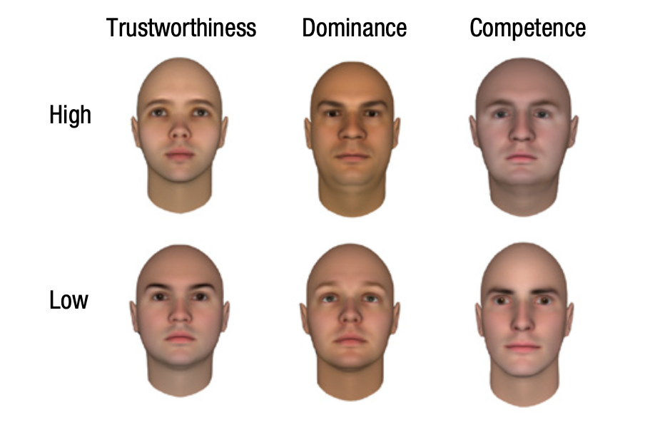

Figure 1: Sample stimuli from the three stimulus sets used in Experiment 1. Each stimulus set included three faces that are perceived as high (+3 SD from the average face) and three faces that are perceived as low (−3 SD from the average face) on a given trait (trustworthiness, dominance, or competence).

## Experiment 1

### Method

### Results

## Experiment 2

### Method

### Results

## General Discussion

### Author Contributions

### Acknowledgements

### Declaration of Conflicting Interests

### Funding

### Open Practices

### Notes

## References

Cogsdill, Emily J, Alexander T Todorov, Elizabeth S Spelke, and Mahzarin R Banaji. 2014. “Inferring Character from Faces: A Developmental Study.” *Psychological Science* 25 (5): 1132–39. https://doi.org/10.1177/0956797614523297.

Oosterhof, Nikolaas N, and Alexander Todorov. 2008. “The Functional Basis of Face Evaluation.” *Proceedings of the National Academy of Sciences* 105 (32): 11087–92. https://doi.org/10.1073/pnas.0805664105.

Todorov, Alexander, Ron Dotsch, Jenny M Porter, Nikolaas N Oosterhof, and Virginia B Falvello. 2013. “Validation of Data-Driven Computational Models of Social Perception of Faces.” *Emotion* 13 (4): 724. https://doi.org/10.1037/a0032335.

Todorov, Alexander, and Nikolaas N Oosterhof. 2011. “Modeling Social Perception of Faces [Social Sciences].” *IEEE Signal Processing Magazine* 28 (2): 117–22. https://doi.org/10.1109/MSP.2010.940006.

## Reflections

### Generative AI Declaration

Indicate [YES] or [NO] to all statements below to show how you have used generative AI tools in this assignment. You MUST declare all use of AI and take responsibility for the content of the assignment. We consider it a misuse of generative AI if you do not declare all uses, including initial exploration of the subject, literature searching, writing and editing, corrections for grammar and spelling, as well as any other tasks from the course.